# Stout Case Study 1: Linear Regression

Theresa Pham

12/22/2022

```r
loans<-read.csv("loans_full_schema.csv")
glimpse(loans)
```

```
## Rows: 10,000
## Columns: 55
## $ emp_title                        <chr> "global config engineer ", "warehouse~
## $ emp_length                       <int> 3, 10, 3, 1, 10, NA, 10, 10, 10, 3, 1~
## $ state                            <chr> "NJ", "HI", "WI", "PA", "CA", "KY", "~
## $ homeownership                    <chr> "MORTGAGE", "RENT", "RENT", "RENT", "~
## $ annual_income                    <dbl> 90000, 40000, 40000, 30000, 35000, 34~
## $ verified_income                  <chr> "Verified", "Not Verified", "Source V~
## $ debt_to_income                   <dbl> 18.01, 5.04, 21.15, 10.16, 57.96, 6.4~
## $ annual_income_joint              <dbl> NA, NA, NA, NA, 57000, NA, 155000, NA~
## $ verification_income_joint        <chr> "", "", "", "", "Verified", "", "Not ~
## $ debt_to_income_joint             <dbl> NA, NA, NA, NA, 37.66, NA, 13.12, NA,~
## $ delinq_2y                        <int> 0, 0, 0, 0, 0, 1, 0, 1, 1, 0, 0, 0, 0~
## $ months_since_last_delinq         <int> 38, NA, 28, NA, NA, 3, NA, 19, 18, NA~
## $ earliest_credit_line             <int> 2001, 1996, 2006, 2007, 2008, 1990, 2~
```

[output cut: 42 more lines]

**The purpose of this linear regression is to predict interest rates from a feature set of numerical predictors**

## Cleaning

For cleaning purposes, we will select only columns with numeric inputs and omit any NAs.

```r
n_numcols <- unlist(lapply(loans, is.numeric))
sum(n_numcols)  # 42 numeric columns
```

```
## [1] 42
```

```r
loans_numeric <- select_if(loans, is.numeric)
ncol(loans_numeric)   # should have 42 columns
```

```
## [1] 42
```

```r
loans_numeric <- na.omit(loans_numeric)
```

## Building a Model

We will create a correlation matrix to identify which variables have high linear correlations with interest rates.

```r
# Correlation data frame
loans_cor <- loans_numeric %>%
  cor() %>%
  as.data.frame() %>%
  rownames_to_column("var1") %>%
    pivot_longer(-1, names_to = "var2", values_to = "correlation")
# Observations most correlated with interest rate
loans_cor %>%
  filter(var1=="interest_rate") %>%
  filter(correlation > 0.2) %>%
  arrange(-correlation)
```

```
## # A tibble: 5 x 3
##   var1          var2                 correlation
##   <chr>         <chr>                      <dbl>
## 1 interest_rate interest_rate              1
## 2 interest_rate paid_interest              0.496
## 3 interest_rate term                       0.300
## 4 interest_rate inquiries_last_12m         0.276
## 5 interest_rate debt_to_income_joint       0.248
```

```r
top_loans_cor <- loans_cor %>%
  filter(var1 %in% c("interest_rate", "paid_interest", "term", "inquiries_last_12m", "debt_to_income_joint")) %>%
  filter (var2 %in% c("interest_rate", "paid_interest", "term", "inquiries_last_12m", "debt_to_income_joint"))
```

We will create a heat map to identify any confounding variables.

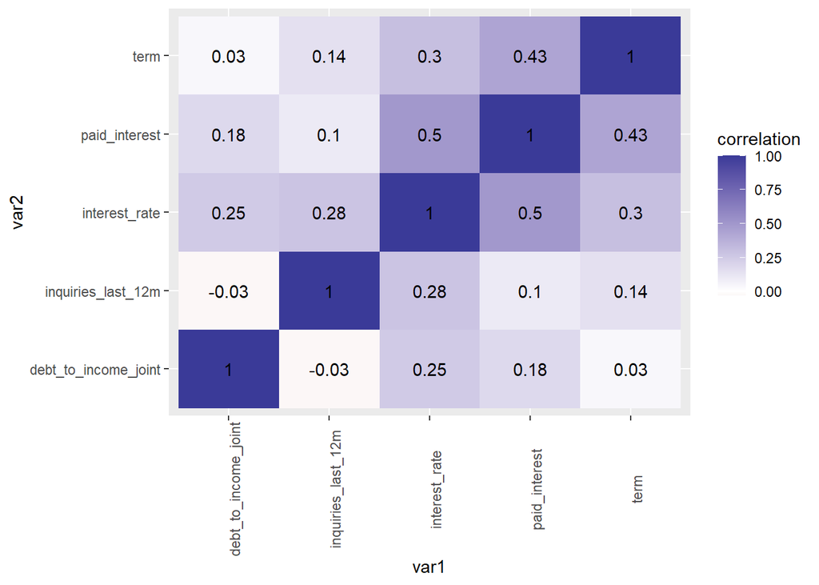

```r
# Correlation Heat Map with top 4 variables correlated with interest rate

top_loans_cor %>%
    ggplot(aes(var1, var2, fill = correlation)) +
  geom_tile() +
  scale_fill_gradient2() +
  geom_text(aes(label = round(correlation,
    2))) +
  theme(axis.text.x = element_text(angle=90))
```

The predictors, “term” and “paid interest”, have a relatively high correlation, thus we well check if they cause discrepancies when running a linear regression.

We will now create a linear model from these four predictors to predict interest rate.

```r
# Split data into train and test sets
top_loans <- loans_numeric %>%
  select(interest_rate, paid_interest, term, inquiries_last_12m, debt_to_income_joint)

set.seed(1)
sort_loans  <- sort(sample(nrow(top_loans), nrow(top_loans)*.7))
lm_train <- top_loans[sort_loans,]
lm_test <- top_loans[-sort_loans,]

# Create linear model from training set

# All 4 variables
ir_lm1 <- lm(interest_rate ~ paid_interest + term + inquiries_last_12m + debt_to_income_joint, data=lm_train)
summary(ir_lm1)
```

```
##
## Call:
## lm(formula = interest_rate ~ paid_interest + term + inquiries_last_12m +
##     debt_to_income_joint, data = lm_train)
##
## Residuals:
##     Min      1Q  Median      3Q     Max
## -9.2442 -3.2736 -0.4711  2.9048 11.1614
##
## Coefficients:
##                       Estimate Std. Error t value Pr(>|t|)
## (Intercept)          6.5433902  1.9133981   3.420 0.000826 ***
## paid_interest        0.0039569  0.0007102   5.571 1.29e-07 ***
## term                 0.0394436  0.0369295   1.068 0.287363
## inquiries_last_12m   0.3050947  0.1438643   2.121 0.035748 *
## debt_to_income_joint 0.1410503  0.0506546   2.785 0.006119 **
## ---
## Signif. codes:  0 '***' 0.001 '**' 0.01 '*' 0.05 '.' 0.1 ' ' 1
##
## Residual standard error: 4.635 on 137 degrees of freedom
## Multiple R-squared:  0.3352, Adjusted R-squared:  0.3158
## F-statistic: 17.27 on 4 and 137 DF,  p-value: 1.71e-11
```

```r
# Exclude "term" as predictor
ir_lm2 <- lm(interest_rate ~ paid_interest + inquiries_last_12m + debt_to_income_joint, data=lm_train)
summary(ir_lm2)
```

```
##
## Call:
## lm(formula = interest_rate ~ paid_interest + inquiries_last_12m +
##     debt_to_income_joint, data = lm_train)
##
## Residuals:
##     Min      1Q  Median      3Q     Max
## -8.8243 -3.1393 -0.6439  2.6916 11.1715
##
## Coefficients:
##                       Estimate Std. Error t value Pr(>|t|)
## (Intercept)          8.1372079  1.1982526   6.791 3.04e-10 ***
## paid_interest        0.0043005  0.0006335   6.788 3.08e-10 ***
## inquiries_last_12m   0.3212956  0.1431354   2.245  0.02638 *
## debt_to_income_joint 0.1370092  0.0505389   2.711  0.00756 **
## ---
## Signif. codes:  0 '***' 0.001 '**' 0.01 '*' 0.05 '.' 0.1 ' ' 1
##
## Residual standard error: 4.637 on 138 degrees of freedom
## Multiple R-squared:  0.3297, Adjusted R-squared:  0.3151
## F-statistic: 22.62 on 3 and 138 DF,  p-value: 5.659e-12
```

```r
# Wald test for "term" and "paid interest"
wald.test(Sigma = vcov(ir_lm1), b = coef(ir_lm1), Terms = 1:2)
```

```
## Wald test:
## ----------
##
## Chi-squared test:
## X2 = 37.1, df = 2, P(> X2) = 8.7e-09
```

We will proceed with the full multiple linear regression in which the four numeric variables, “paid_interest”, “term”, “inquiries_last_12m”, and “debt_to_income_joint” are used to predict interest rate.

## Evaluate Model

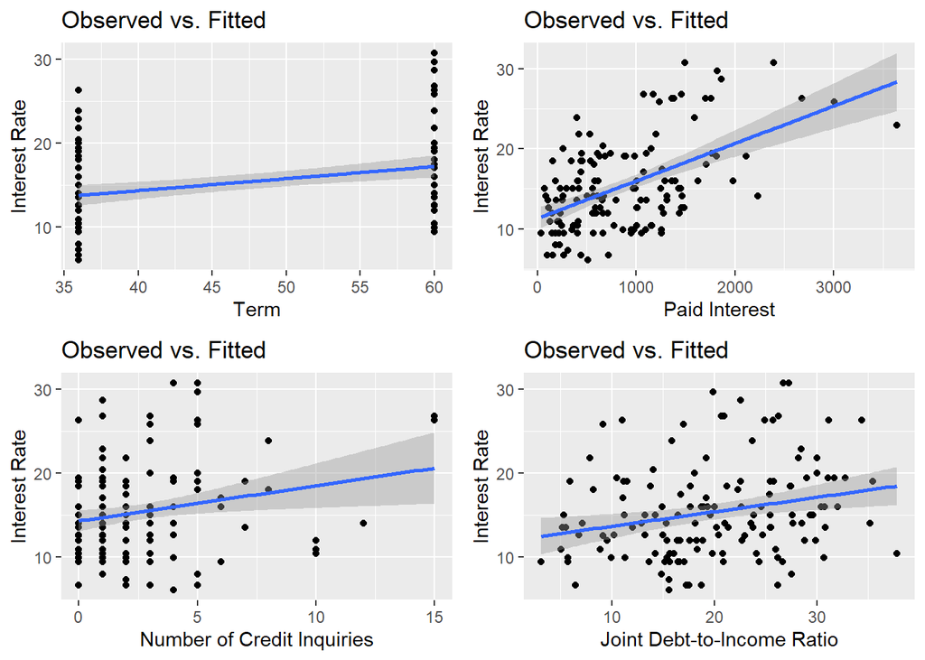

```r
par(mfrow=c(2,2))

fit1 <- ggplot(lm_train, aes(x=term, y=interest_rate)) +
  geom_point() +
  geom_smooth(method=lm) +
  ggtitle("Observed vs. Fitted") +
  labs(x="Term", y="Interest Rate")

fit2 <- ggplot(lm_train, aes(x=paid_interest, y=interest_rate)) +
  geom_point() +
  geom_smooth(method=lm) +
  ggtitle("Observed vs. Fitted") +
  labs(x="Paid Interest", y="Interest Rate")

fit3 <- ggplot(lm_train, aes(x=inquiries_last_12m, y=interest_rate)) +
  geom_point() +
  geom_smooth(method=lm) +
  ggtitle("Observed vs. Fitted") +
  labs(x="Number of Credit Inquiries", y="Interest Rate")

fit4 <- ggplot(lm_train, aes(x=debt_to_income_joint, y=interest_rate)) +
  geom_point() +
  geom_smooth(method=lm) +
  ggtitle("Observed vs. Fitted") +
  labs(x="Joint Debt-to-Income Ratio", y="Interest Rate")

grid.arrange(fit1, fit2, fit3, fit4, nrow = 2)
```

The first assumption of the linear model is that all predictors have a relatively linear relationship with interest rate.

We will plot the residuals, a normal QQ plot, and the distribution of residuals to check more assumptions of a linear regression.

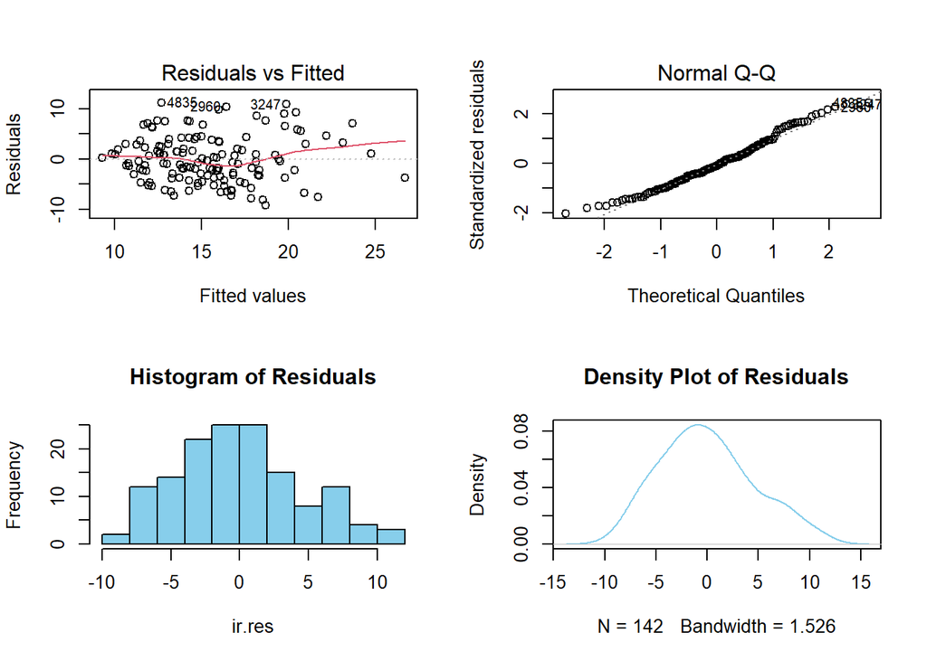

```r
par(mfrow=c(2,2))

plot(ir_lm1, which = c(1,2))

ir.res <- resid(ir_lm1)
hist(ir.res,
     main = "Histogram of Residuals",
     col = "sky blue")
plot(density(ir.res),
     main = "Density Plot of Residuals",
     col = "sky blue")
```

We will now evaluate the model with the test set by evaluating the plot and RMSE of actual vresus predicted interest rates.

```r
# Data frame of actual and predicted interest rates on test set
ir_lm1_pred <- as.data.frame(predict(ir_lm1, newdata=lm_test))
#lm_test
#ir_lm1_pred

lm_test_df <- data.frame(lm_test$interest_rate, ir_lm1_pred)
colnames(lm_test_df)[1] <- "Actual"
colnames(lm_test_df)[2] <- "Predicted"
head(lm_test_df)
```

```
##     Actual Predicted
## 100  20.00  16.15477
## 131   6.72  13.36920
## 215   9.44  13.57776
## 353   7.35  12.89706
## 412  15.04  15.71687
## 517  11.99  14.85798
```

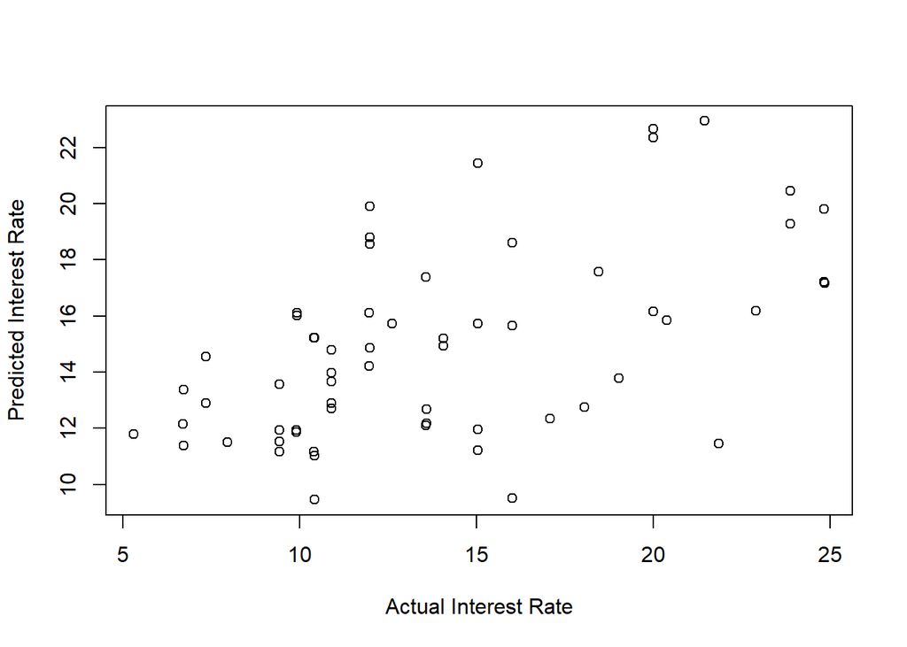

```r
# Actual vs Predicted
plot(lm_test_df$Actual, lm_test_df$Predicted,
     xlab = "Actual Interest Rate",
     ylab = "Predicted Interest Rate")
```

```r
# RMSE
lm_rmse <- rmse(lm_test_df$Actual, lm_test_df$Predicted)
lm_rmse
```

```
## [1] 4.471899
```

On average, the predicted value will be off by 4.472 from the actual value.

## Proposed Enhancements

If given more time, some enhancements I would add to the model would be to consider non-numerical variables as well, because many of the columns in the data set were non numerical. Another enhancement would be to consider possible interactions between variables to enhance the model, or perhaps transform the model so that it is more linear.